# Statistics for Decision Making

## Question 3: Binomial Probability — No Car Parking (Abbotsford)

**Question:** For Abbotsford, what is the probability that out of 10 properties sold, exactly 3 will NOT have a car parking space? **Approach:** Estimate P(no car) from data → apply Binomial distribution.

```python
abbotsford = df[df['Suburb'] == 'Abbotsford'].copy()
car_data   = abbotsford['Car'].dropna()

print("=== Car Parking Distribution — Abbotsford ===")
print(car_data.value_counts().sort_index().to_string())

no_car_count = (car_data == 0).sum()
p_no_car     = no_car_count / len(car_data)

print(f"\n  Total properties with car data : {len(car_data)}")
print(f"  Properties with NO car parking : {no_car_count}")
print(f"  P(no car parking)              : {p_no_car:.4f} ({p_no_car*100:.2f}%)")

n, k = 10, 3
prob = binom.pmf(k, n, p_no_car)

print("\n=== Binomial Probability Calculation ===")
print(f"  Formula: P(X=k) = C(n,k) x p^k x (1-p)^(n-k)")
print(f"  n={n}, k={k}, p={p_no_car:.4f}")
print(f"\n  P(exactly 3 out of 10 have NO car parking) = {prob:.3f}")
```

```
=== Car Parking Distribution — Abbotsford ===
Car
0.0    15
1.0    29
2.0    12

  Total properties with car data : 56
  Properties with NO car parking : 15
  P(no car parking)              : 0.2679 (26.79%)

=== Binomial Probability Calculation ===
  Formula: P(X=k) = C(n,k) x p^k x (1-p)^(n-k)
  n=10, k=3, p=0.2679

  P(exactly 3 out of 10 have NO car parking) = 0.260
```

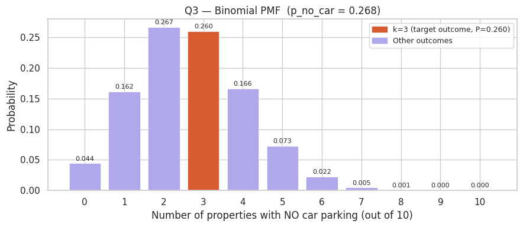

```python
xs   = range(0, n + 1)
pmfs = [binom.pmf(x, n, p_no_car) for x in xs]
colors = ['#D85A30' if x == 3 else '#AFA9EC' for x in xs]

fig, ax = plt.subplots(figsize=(9, 4))
bars = ax.bar(xs, pmfs, color=colors, edgecolor='white', linewidth=0.5)
ax.bar_label(bars, fmt='%.3f', fontsize=8, padding=2)
ax.set_xlabel('Number of properties with NO car parking (out of 10)')
ax.set_ylabel('Probability')
ax.set_title(f'Q3 — Binomial PMF  (p_no_car = {p_no_car:.3f})')
ax.set_xticks(list(xs))
ax.legend(handles=[Patch(color='#D85A30', label='k=3 (target outcome, P=0.260)'),
                   Patch(color='#AFA9EC', label='Other outcomes')], fontsize=9)
plt.tight_layout()
plt.show()
```

```python
print("Chart: Q3 — Binomial Probability Mass Function (PMF)")
print("Description: Each bar = probability of exactly k properties (out of 10) having no car parking. Orange bar highlights the target k=3, with P = 0.260.")
```

```
Chart: Q3 — Binomial Probability Mass Function (PMF)
Description: Each bar = probability of exactly k properties (out of 10) having no car parking. Orange bar highlights the target k=3, with P = 0.260.
```

## Question 4: Probability of 3-Room Property (Abbotsford)

**Question:** In the suburb of Abbotsford, what are the chances of finding a property with 3 rooms?

```python
rooms = abbotsford['Rooms']
total = len(rooms)
three_room_count = (rooms == 3).sum()
prob_3rooms = three_room_count / total

print("=== Room Distribution — Abbotsford ===")
print(rooms.value_counts().sort_index().to_string())
print(f"\n  Total Abbotsford properties : {total}")
print(f"  Properties with 3 rooms     : {three_room_count}")
print(f"\n  P(3 rooms) = {three_room_count}/{total} = {prob_3rooms:.3f}")
```

```
=== Room Distribution — Abbotsford ===
Rooms
1     5
2    27
3    20
4     4

  Total Abbotsford properties : 56
  Properties with 3 rooms     : 20

  P(3 rooms) = 20/56 = 0.357
```

## Question 5: Probability of 2-Bathroom Property (Abbotsford)

**Question:** In the suburb of Abbotsford, what are the chances of finding a property with 2 bathrooms?

```python
bath = abbotsford['Bathroom'].dropna()
total_bath     = len(bath)
two_bath_count = (bath == 2).sum()
prob_2bath     = two_bath_count / total_bath

print("=== Bathroom Distribution — Abbotsford ===")
print(bath.value_counts().sort_index().to_string())
print(f"\n  Total Abbotsford properties (with bathroom data) : {total_bath}")
print(f"  Properties with 2 bathrooms                      : {two_bath_count}")
print(f"\n  P(2 bathrooms) = {two_bath_count}/{total_bath} = {prob_2bath:.3f}")
```

```
=== Bathroom Distribution — Abbotsford ===
Bathroom
1.0    35
2.0    19
3.0     2

  Total Abbotsford properties (with bathroom data) : 56
  Properties with 2 bathrooms                      : 19

  P(2 bathrooms) = 19/56 = 0.339
```

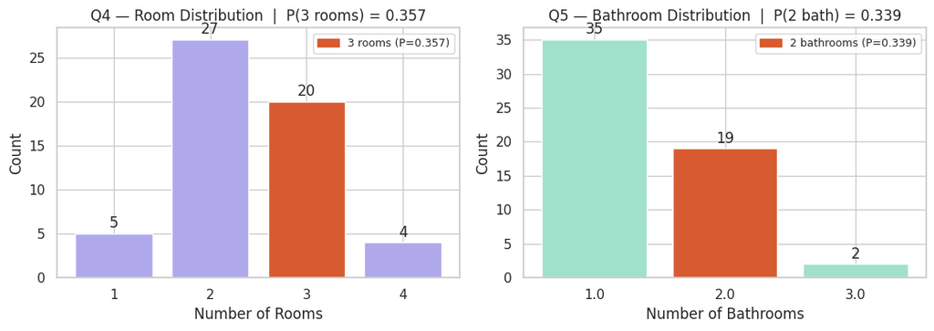

```python
fig, axes = plt.subplots(1, 2, figsize=(11, 4))

room_counts   = abbotsford['Rooms'].value_counts().sort_index()
bar_colors_r  = ['#D85A30' if r == 3 else '#AFA9EC' for r in room_counts.index]
b1 = axes[0].bar(room_counts.index.astype(str), room_counts.values, color=bar_colors_r)
axes[0].bar_label(b1, fmt='%d', padding=2)
axes[0].set_title(f'Q4 — Room Distribution  |  P(3 rooms) = {prob_3rooms:.3f}')
axes[0].set_xlabel('Number of Rooms')
axes[0].set_ylabel('Count')
axes[0].legend(handles=[Patch(color='#D85A30', label=f'3 rooms (P={prob_3rooms:.3f})')], fontsize=9)

bath_counts   = abbotsford['Bathroom'].dropna().value_counts().sort_index()
bar_colors_b  = ['#D85A30' if b == 2 else '#9FE1CB' for b in bath_counts.index]
b2 = axes[1].bar(bath_counts.index.astype(str), bath_counts.values, color=bar_colors_b)
axes[1].bar_label(b2, fmt='%d', padding=2)
axes[1].set_title(f'Q5 — Bathroom Distribution  |  P(2 bath) = {prob_2bath:.3f}')
axes[1].set_xlabel('Number of Bathrooms')
axes[1].set_ylabel('Count')
axes[1].legend(handles=[Patch(color='#D85A30', label=f'2 bathrooms (P={prob_2bath:.3f})')], fontsize=9)

plt.tight_layout()
plt.show()
```

```python
print("Chart: Q4 & Q5 — Bar Charts: Room & Bathroom Distributions (Abbotsford)")
print("Description: Left (Q4): orange bar = 3-room properties, P = 0.357. Right (Q5): orange bar = 2-bathroom properties, P = 0.339.")
```

```
Chart: Q4 & Q5 — Bar Charts: Room & Bathroom Distributions (Abbotsford)
Description: Left (Q4): orange bar = 3-room properties, P = 0.357. Right (Q5): orange bar = 2-bathroom properties, P = 0.339.
```

## Question 6: One-Sample T-Test — Richmond Industry Pricing Claim

**Claim:** A real estate firm claims the average property price in Richmond is $1,000,000. Test whether the actual average is significantly different at α = 0.05.

```python
richmond = df[df['Suburb'] == 'Richmond']['Price'].dropna()

print("=== Descriptive Statistics — Richmond ===")
print(f"  n       : {len(richmond)}")
print(f"  Mean    : ${richmond.mean():,.2f}")
print(f"  Median  : ${richmond.median():,.2f}")
print(f"  Std Dev : ${richmond.std():,.2f}")

mu_0 = 1_000_000
print("\n=== Null and Alternative Hypotheses ===")
print("  H0: mu = $1,000,000  (firm's claim is correct)")
print("  H1: mu != $1,000,000  (actual mean is significantly different — two-tailed)")

t_stat, p_val = ttest_1samp(richmond, popmean=mu_0)

print("\n=== Test Statistic & P-Value ===")
print(f"  Test Statistic (t) : {t_stat:.4f}")
print(f"  P-Value            : {p_val:.4f}")

print("\n=== Final Business Conclusion ===")
if p_val < 0.05:
    direction = "above" if richmond.mean() > mu_0 else "below"
    print(f"  Decision : REJECT H0  (p = {p_val:.4f} < 0.05)")
    print(f"  The actual mean (${richmond.mean():,.0f}) is significantly {direction} $1,000,000.")
    print("  The firm's pricing claim of $1,000,000 is NOT supported by the data.")
    print(f"  Recommendation: Update valuations to reflect the actual mean of ${richmond.mean():,.0f}.")
else:
    print(f"  Decision : FAIL TO REJECT H0  (p = {p_val:.4f} >= 0.05)")
    print("  Data is consistent with the $1,000,000 claim.")
```

```
=== Descriptive Statistics — Richmond ===
  n       : 260
  Mean    : $1,083,564.42
  Median  : $1,078,000.00
  Std Dev : $522,353.52

=== Null and Alternative Hypotheses ===
  H0: mu = $1,000,000  (firm's claim is correct)
  H1: mu != $1,000,000  (actual mean is significantly different — two-tailed)

=== Test Statistic & P-Value ===
  Test Statistic (t) : 2.5795
  P-Value            : 0.0104

=== Final Business Conclusion ===
  Decision : REJECT H0  (p = 0.0104 < 0.05)
  The actual mean ($1,083,564) is significantly above $1,000,000.
  The firm's pricing claim of $1,000,000 is NOT supported by the data.
  Recommendation: Update valuations to reflect the actual mean of $1,083,564.
```

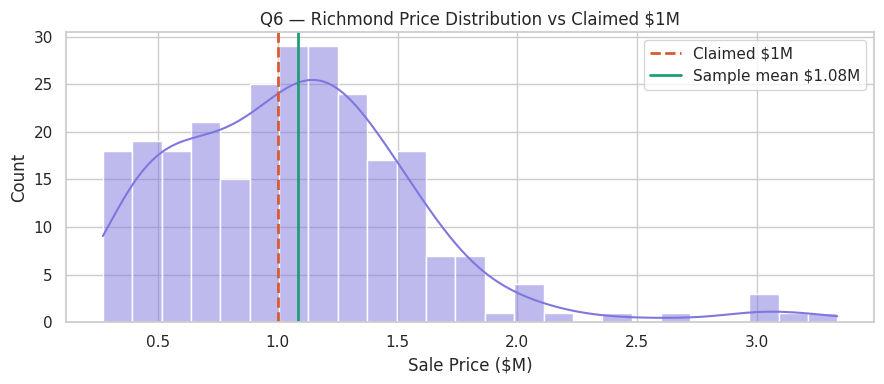

```python
fig, ax = plt.subplots(figsize=(9, 4))
data_r = richmond / 1e6
sns.histplot(data_r, bins=25, kde=True, ax=ax, color="#7F77DD")
ax.axvline(1.0, color="#D85A30", lw=2, ls="--", label="Claimed $1M")
ax.axvline(data_r.mean(), color="#1D9E75", lw=2, ls="-",
           label=f"Sample mean ${data_r.mean():.2f}M")
ax.set_xlabel("Sale Price ($M)")
ax.set_ylabel("Count")
ax.set_title("Q6 — Richmond Price Distribution vs Claimed $1M")
ax.legend()
plt.tight_layout()
plt.show()
```

```python
print("Chart: Q6 — Histogram with KDE")
print("Description: Distribution of Richmond sale prices. Red dashed = firm's claimed $1M; green = actual sample mean ($1.08M). Gap confirms H0 is rejected.")
```

```
Chart: Q6 — Histogram with KDE
Description: Distribution of Richmond sale prices. Red dashed = firm's claimed $1M; green = actual sample mean ($1.08M). Gap confirms H0 is rejected.
```

## Question 7: Independent Two-Sample T-Test — Car Parking Effect on Price

**Question:** Do properties with car parking sell at a higher average price than those without? **Significance level:** α = 0.05

```python
car_df      = df[['Price', 'Car']].dropna()
with_car    = car_df[car_df['Car'] > 0]['Price']
without_car = car_df[car_df['Car'] == 0]['Price']

print("=== Descriptive Statistics ===")
print(f"  WITH car parking    : n={len(with_car):,},  Mean=${with_car.mean():,.2f}")
print(f"  WITHOUT car parking : n={len(without_car):,},  Mean=${without_car.mean():,.2f}")
print(f"  Observed difference : ${with_car.mean() - without_car.mean():,.2f}")

print("\n=== Choice of Test ===")
print("  Welch's Independent Two-Sample T-Test (one-tailed right)")
print("  Justification:")
print("    - Two independent groups (with vs without car parking)")
print("    - Continuous outcome variable (Price)")
print("    - Unequal sample sizes → Welch's handles unequal variances")
print("    - Directional claim (with > without) → one-tailed right")

print("\n=== Hypotheses ===")
print("  H0: mu_with_car <= mu_without_car  (no price premium for car parking)")
print("  H1: mu_with_car  > mu_without_car  (car parking commands higher price)")

t_stat, p_two = ttest_ind(with_car, without_car, equal_var=False)
p_one = p_two / 2

print("\n=== Test Results ===")
print(f"  T-statistic        : {t_stat:.4f}")
print(f"  Two-tailed p-value : {p_two:.4f}")
print(f"  One-tailed p-value : {p_one:.4f}")

print("\n=== P-Value Interpretation & Business Implications ===")
print(f"  p = {p_one:.4f} > 0.05 → FAIL TO REJECT H0")
print("  Car parking does NOT significantly raise sale price across the full dataset.")
print("  The mean difference is negligible ($-4,644 — properties WITHOUT car are marginally higher).")
print("\n  Business Implications for Developers:")
print("    → Car parking alone is NOT a statistically proven price driver.")
print("    → Suburb, property type, and size dominate pricing more than car parking.")
print("    → Do not assume a blanket price premium from adding car spaces.")
```

```
=== Descriptive Statistics ===
  WITH car parking    : n=12,492,  Mean=$1,074,443.92
  WITHOUT car parking : n=1,026,  Mean=$1,079,088.01
  Observed difference : $-4,644.09

=== Choice of Test ===
  Welch's Independent Two-Sample T-Test (one-tailed right)
  Justification:
    - Two independent groups (with vs without car parking)
    - Continuous outcome variable (Price)
    - Unequal sample sizes → Welch's handles unequal variances
    - Directional claim (with > without) → one-tailed right

=== Hypotheses ===
  H0: mu_with_car <= mu_without_car  (no price premium for car parking)
  H1: mu_with_car  > mu_without_car  (car parking commands higher price)

=== Test Results ===
  T-statistic        : -0.2722
  Two-tailed p-value : 0.7855
  One-tailed p-value : 0.3927

=== P-Value Interpretation & Business Implications ===
  p = 0.3927 > 0.05 → FAIL TO REJECT H0
  Car parking does NOT significantly raise sale price across the full dataset.
  The mean difference is negligible ($-4,644 — properties WITHOUT car are marginally higher).

  Business Implications for Developers:
    → Car parking alone is NOT a statistically proven price driver.
    → Suburb, property type, and size dominate pricing more than car parking.
    → Do not assume a blanket price premium from adding car spaces.
```

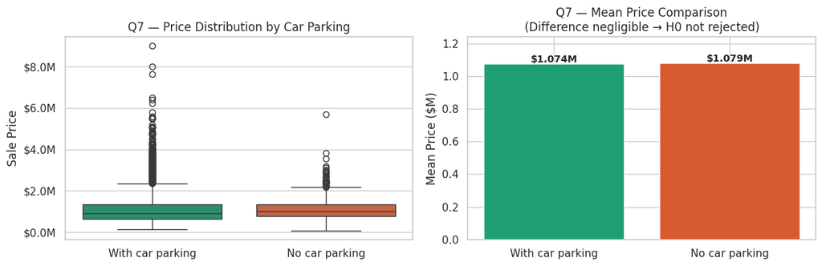

```python
fig, axes = plt.subplots(1, 2, figsize=(12, 4))

car_df2 = df[['Price','Car']].dropna().copy()
car_df2['Parking'] = car_df2['Car'].apply(
    lambda x: 'With car parking' if x > 0 else 'No car parking')

sns.boxplot(data=car_df2, x='Parking', y='Price',
            order=['With car parking','No car parking'],
            palette=['#1D9E75','#D85A30'], ax=axes[0])
axes[0].yaxis.set_major_formatter(plt.FuncFormatter(lambda x, _: f'${x/1e6:.1f}M'))
axes[0].set_title('Q7 — Price Distribution by Car Parking')
axes[0].set_xlabel('')
axes[0].set_ylabel('Sale Price')

means = car_df2.groupby('Parking')['Price'].mean()
bars  = axes[1].bar(['With car parking','No car parking'],
                    [means.get('With car parking',0)/1e6, means.get('No car parking',0)/1e6],
                    color=['#1D9E75','#D85A30'], edgecolor='white')
for bar, val in zip(bars, [means.get('With car parking',0), means.get('No car parking',0)]):
    axes[1].text(bar.get_x()+bar.get_width()/2, val/1e6+0.01,
                 f'${val/1e6:.3f}M', ha='center', fontsize=10, fontweight='bold')
axes[1].set_title('Q7 — Mean Price Comparison\n(Difference negligible → H0 not rejected)')
axes[1].set_ylabel('Mean Price ($M)')
axes[1].set_ylim(0, max(means.values)/1e6 * 1.15)
plt.tight_layout()
plt.show()
```

```python
print("Chart: Q7 — Box Plot & Mean Comparison Bar Chart")
print("Description: Left: price spread for properties with vs without car parking. Right: mean prices are almost identical (difference = -$4,644), confirming no statistically significant premium from car parking (p = 0.393, H0 not rejected).")
```

```
Chart: Q7 — Box Plot & Mean Comparison Bar Chart
Description: Left: price spread for properties with vs without car parking. Right: mean prices are almost identical (difference = -$4,644), confirming no statistically significant premium from car parking (p = 0.393, H0 not rejected).
```

## Question 8: Two-Way ANOVA — Location & Property Type Effect on Price

**Task:** Investigate whether property prices are influenced by Suburb, Type of property, and their interaction. **Top 5 suburbs by listing volume used** for a robust, balanced analysis.

```python
top_suburbs = df['Suburb'].value_counts().head(5).index.tolist()
anova_df    = df[df['Suburb'].isin(top_suburbs)][['Price','Suburb','Type']].dropna()

print("=== ANOVA Dataset ===")
print(f"  Suburbs used   : {top_suburbs}")
print(f"  Property types : {sorted(anova_df['Type'].unique())}  (h=house, t=townhouse, u=unit)")
print(f"  Total records  : {len(anova_df):,}")

print("\n=== Mean Price by Suburb ===")
print(anova_df.groupby('Suburb')['Price'].mean().apply(lambda x: f'${x:,.0f}').to_string())
print("\n=== Mean Price by Property Type ===")
type_map = {'h':'House','t':'Townhouse','u':'Unit/Apartment'}
for t, m in anova_df.groupby('Type')['Price'].mean().items():
    print(f"  {type_map.get(t,t):15s}: ${m:,.0f}")

model     = ols('Price ~ C(Suburb) + C(Type) + C(Suburb):C(Type)', data=anova_df).fit()
anova_tbl = anova_lm(model, typ=2)

print("\n=== Two-Way ANOVA Table (Type II SS) ===")
print(anova_tbl.to_string())

labels = {
    'C(Suburb)'         : 'Suburb (main effect)',
    'C(Type)'           : 'Property Type (main effect)',
    'C(Suburb):C(Type)' : 'Suburb x Type (interaction)',
}
print("\n=== Factor Significance (alpha = 0.05) ===")
for factor in anova_tbl.index:
    p = anova_tbl.loc[factor, 'PR(>F)']
    if pd.notna(p):
        sig  = "SIGNIFICANT" if p < 0.05 else "Not significant"
        print(f"  {labels.get(factor,factor):40s}: p={p:.2e}  =>  {sig}")

print("\n=== Business Conclusions ===")
print("  1. Suburb significantly affects price — location is the primary value driver.")
print("  2. Property type significantly affects price — houses > townhouses > units.")
print("  3. Interaction is also significant — suburb x type combos must be evaluated together.")
```

[output not shown]

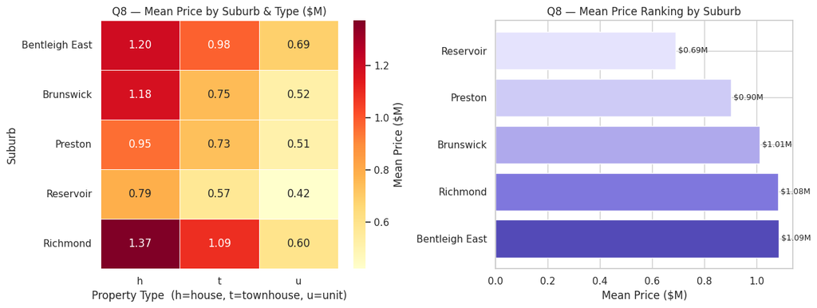

```python
fig, axes = plt.subplots(1, 2, figsize=(13, 5))

pivot = anova_df.groupby(['Suburb','Type'])['Price'].mean().unstack().fillna(0) / 1e6
sns.heatmap(pivot, annot=True, fmt='.2f', cmap='YlOrRd', ax=axes[0],
            linewidths=0.5, cbar_kws={'label':'Mean Price ($M)'})
axes[0].set_title('Q8 — Mean Price by Suburb & Type ($M)')
axes[0].set_xlabel('Property Type  (h=house, t=townhouse, u=unit)')
axes[0].set_ylabel('Suburb')

means_suburb = anova_df.groupby('Suburb')['Price'].mean().sort_values(ascending=False)
colors_s = ['#534AB7','#7F77DD','#AFA9EC','#CECBF6','#E5E3FD']
axes[1].barh(means_suburb.index, means_suburb.values/1e6, color=colors_s)
axes[1].set_title('Q8 — Mean Price Ranking by Suburb')
axes[1].set_xlabel('Mean Price ($M)')
for i, val in enumerate(means_suburb.values):
    axes[1].text(val/1e6+0.01, i, f'${val/1e6:.2f}M', va='center', fontsize=9)
plt.tight_layout()
plt.show()
```

```python
print("Chart: Q8 — Heatmap & Suburb Mean Bar Chart")
print("Description: Left: mean price ($M) by suburb x property type — darker = higher price; houses consistently outprice units across all suburbs. Right: suburb price ranking showing which locations command the highest premiums.")
```

```
Chart: Q8 — Heatmap & Suburb Mean Bar Chart
Description: Left: mean price ($M) by suburb x property type — darker = higher price; houses consistently outprice units across all suburbs. Right: suburb price ranking showing which locations command the highest premiums.
```